# Milestone 1 - Groups, data, and website

## Milestone 2

### Possible sources of data

1. Boston Airbnb open data (Kaggle): https://www.kaggle.com/airbnb/boston
2. Washintgon Airbnb open data (data.world): https://data.world/codefordc/airbnb-washington-d-c-2015-10-03
3. San Francisco Airbnb open data (data.world): https://data.world/ajsanne/sf-airbnb-listings
4. New York Airbnb open data (Kaggle): https://www.kaggle.com/dgomonov/new-york-city-airbnb-open-data

### Project Plan

Since the first time Airbnb was established in 2008, its appearance has disrupted and changed the traditional ways of hospitality and acoomodation around the world. The number of rental listings on Airbnb has expanded exponentially over the past few years. Based on the motivation to understand its explosive growth thoroughly, this project aims to extract data from websites, manipulate it, run exploratory analysis on procesed one, apply machine learning models, and finally suggest possible ideas to help owners or customers to choose the best accomodation they need.

### Possible tools

Python libraries:

```
1. Data extraction and manipulation: numpy, pandas
2. Data visualization: plotly, seaborn, ipywidgets, and matplotlib
3. Data analysis: scipy and scikit-learn
```

Others: Natural language processing (NLP) and linear regression.

## Import necessary libraries and set up the environment

```python
import pandas as pd
import numpy as np
import scipy.stats as stat
import matplotlib.pyplot as plt
import seaborn as sb
from pygal import *
from IPython.display import SVG, HTML
init_notebook_mode(connected=True)
sb.set()
```

## Data Extraction & Data Warehousing

We load the datasets locally, and it consists of 3 cities in the U.S, include Boston, New York, and Washington D.C. First of all, we will clean and explore more deeply New York datasets through graphs, statistics, and machine learning model. Later, we will compare it with the two remaining processed datasets. Also, we will take a look at the dimension of NY dataset for later analysis.

```python
# Boston datasets
listing = "../Airbnb-Datasets/Boston/listings.csv"
boston_listings = pd.read_csv(listing)

# Washington datasets
listing = "../Airbnb-Datasets/Washington/Listings - Detailed.csv"
was_listings = pd.read_csv(listing)

# New York datasets
listing_kaggle = "../Airbnb-Datasets/New York/AB_NYC_2019.csv"
listing = "../Airbnb-Datasets/New York/airbnb-listings.csv"
ny_listing_kaggle = pd.read_csv(listing_kaggle)
ny_listings = pd.read_csv(listing, sep=';',low_memory=False)

print("NY dataset's dimension: %dx%d" % (ny_listings.shape))
```

```
NY dataset's dimension: 19528x89
```

## Data Cleaning

### Data Separation

If we look at the NY dataset's dimension, we could see that the see that it is huge and we should be happy about it! However, it comes with a dark side because it makes harder for us to remember and choose the best columns for data analysis. Therefore, we will divide this dataset into 6 sub-categories, including text, host, location, house, money, and review. Below are the information about each table.

1. text: include customers' reviews and general descriptions for each Airbnb listing. These are essential fuel for us to understand the customers more via Natural Language Processing (NLP). All columns are categorical.
2. host: include necessary information about each host. This column can help us analyze the hosts' performances and how it will correlate with other features, particulatly ones in "money" table. Columns are both numerical and categorical.
3. location: include information about location of each listing. This column is important for us to analyze price and review scores at specific location on map. Columns are both numerical and categorical.
4. house: include characteristics of each Airbnb listing. This table can help us see how its features are going to affect the price. Columns are both numerical and categorical.
5. money: include price and availability. This is interesting table since we will run linear regression model for multivariate variables and derive the hypothesis function to predict the renting price. Columns are all numerical.
6. review: include all kinds of rating scores. Similar to "host" table, we are going to understand how reviews influence the hosts' decision to set the price. Columns are both numerical and categorical.

```python
#ny_listings = ny_listings.set_index("ID")
# Divide the dataset into 6 sub-categories, including text, host, location, house, money, and review
# All shared same ID
text = ['Description','Summary','Experiences Offered', 'Neighborhood Overview', 'Notes']

host = ['Host ID', 'Host Since', 'Host Location', 'Host About','Host Listings Count',
        'Host Response Time', 'Host Response Rate','Host Verifications']

location = ['Street', 'Neighbourhood', 'City','State', 'Zipcode', 'Market',
            'Smart Location', 'Country Code','Country', 'Latitude', 'Longitude']

house = ['Property Type', 'Room Type','Accommodates', 'Bathrooms', 'Bedrooms', 'Beds',
         'Bed Type','Amenities', 'Square Feet','Calculated host listings count']

money = ['Price', 'Weekly Price', 'Monthly Price', 'Cleaning Fee', 'Availability 30',
         'Availability 60','Availability 90', 'Availability 365']

review = ['Number of Reviews', 'First Review', 'Last Review','Review Scores Rating','Reviews per Month',
          'Review Scores Accuracy','Review Scores Cleanliness', 'Review Scores Checkin',
          'Review Scores Communication', 'Review Scores Location','Review Scores Value']

text_df, host_df, location_df = ny_listings[text].copy(), ny_listings[host].copy(), ny_listings[location].copy()
house_df, money_df, review_df = ny_listings[house].copy(), ny_listings[money].copy(), ny_listings[review].copy()
```

### Deal with missing data

Fortunately, the datasets we downloaded online are tidy and did not have any serious quality issues. However, if we skim over it, we can easily spot out the missing data. Thus, we will replace missing values with its mean for numerical values if the missing values account for more than 30% of their total elements. Otherwise, we will just drop them all. For categorical ones, we will fill missing data with "Not Provided" string if the missing values are more than 50% of total elements.

```python
# Create a helper function to replace missing values
def fill_missing(df):
    columns = df.columns.values
    for each in columns:
        column, name = df[each], df[each].name
        if column.dtypes == 'int64':
            miss_percent = column.isnull().sum()/len(column) > 0.3
            df.fillna(value={name:column.mean()},inplace=True) if miss_percent else df.dropna(subset=[each],inplace=True)

        elif column.dtypes == 'float64':
            miss_percent = column.isnull().sum()/len(column) > 0.3
            df.fillna(value={name:column.mean()},inplace=True) if miss_percent else df.dropna(subset=[each],inplace=True)

        elif column.dtypes == 'object':
            miss_percent = column.isnull().sum()/len(column) > 0.5
            df.fillna(value={name:'Not provided'},inplace=True) if miss_percent else df.dropna(subset=[each],inplace=True)

df_lists = [text_df, host_df, location_df, house_df, money_df, review_df]
for each in df_lists:
    fill_missing(each)
```

### Exploratory Data Analysis

#### Scatter Plot

First of all, we are interested in finding the correlation among features. For example, we want to see the correlation between number of reviews for each listing and its price or the host response rate and review scores rating by using scatter plot and critical lines.

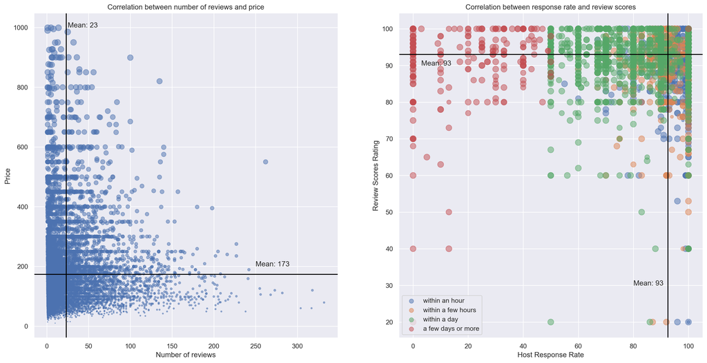

```python
# Create a figure and 2 subplots
fig, axes = plt.subplots(nrows=1,ncols=2,figsize=(20,10), dpi=200)
#Price and review per month
money_review = money_df.merge(review_df, how='inner', left_index=True, right_index=True)
axes[0].scatter('Number of Reviews','Price',data=money_review, s=money_review['Price']/10,c='b',alpha=0.5)
axes[0].set(xlabel='Number of reviews',ylabel='Price', title='Correlation between number of reviews and price')

#Annotate the axis lines with their means
axes[0].axhline(money_review['Price'].mean(),c='black')
axes[0].text(250,200,'Mean: {}'.format(round(money_review['Price'].mean())))
axes[0].axvline(money_review['Number of Reviews'].mean(),c='black')
axes[0].text(25,1000,'Mean: {}'.format(round(money_review['Number of Reviews'].mean())))

#Host response rate and review scores rating
host_review = host_df.merge(review_df, how='inner', left_index=True, right_index=True)
for each in host_review['Host Response Time'].unique():
    data = host_review[host_review['Host Response Time'] == each]
    axes[1].scatter('Host Response Rate','Review Scores Rating',data=data,
                      label=each,s=host_review['Host Response Rate'],alpha=0.5)
axes[1].set(xlabel='Host Response Rate',ylabel='Review Scores Rating',
              title='Correlation between response rate and review scores')

#Annotate the axis lines with their means
axes[1].axhline(host_review['Review Scores Rating'].mean(),c='black')
axes[1].text(3,90,'Mean: {}'.format(round(host_review['Review Scores Rating'].mean())))
axes[1].axvline(host_review['Host Response Rate'].mean(),c='black')
axes[1].text(80,30,'Mean: {}'.format(round(host_review['Host Response Rate'].mean())))

# Add the legend to the second subplot
plt.legend();
```

#### Analysis

For the first subplot, the data points cluster around the intersection between means of both number and reviews and price. This may indicate that when the price is low, there are more number of listings, which seems logical due to the law of supply and demand. Also, we can see that there are many data points that go along its mean axis, which may demonstrate that the price or the number of reviews are not affected by another factor.

#### Joint Plot

Next step, we are going to focus on how other features affect the price. For instance, the plot below shows the correlation between number of rooms and price.

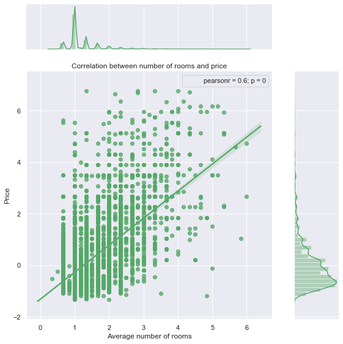

```python
# Average number of rooms and price
house_money = house_df.merge(money_df, how='inner', left_index=True, right_index=True)
house_money['Average rooms'] = house_money[['Bathrooms','Bedrooms','Beds']].mean(axis=1)
std_price = (house_money['Price'] - house_money['Price'].mean()) / house_money['Price'].std()
house_money['Std Price'] = std_price

join = sb.jointplot('Average rooms','Std Price', data=house_money,
                    kind='reg', height=8, ratio=4, color='g',space=0.5)
join = join.annotate(stat.pearsonr)
plt.gca().set(xlabel="Average number of rooms", ylabel='Price',
              title='Correlation between number of rooms and price');
```

#### Box plot

This plot shows the distribution of price of several areas in NYC.

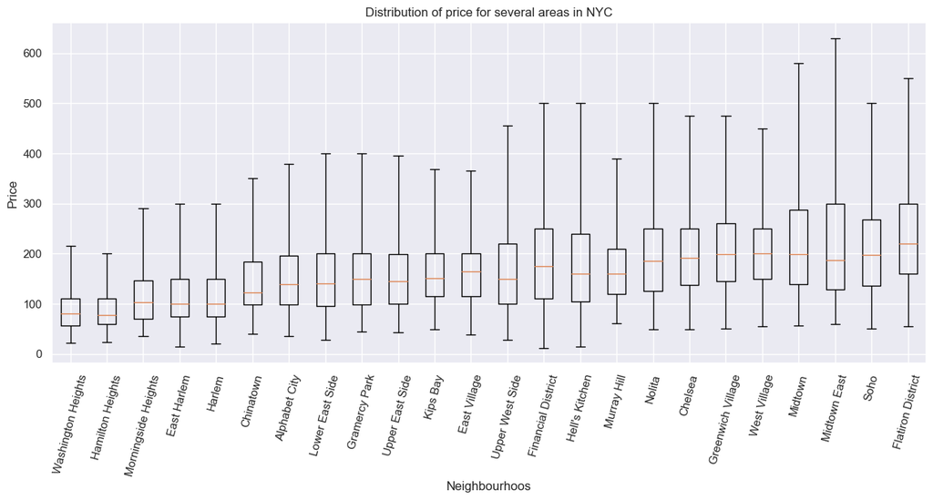

```python
# Price distribution of each location (boxplot)
location_money = location_df.merge(money_df, how='inner', right_index=True, left_index=True)
location = location_money['Neighbourhood'].value_counts()
neighbor = location[location > 100]
price_dist = {i:[0,[]] for i in neighbor.index.values}
for each in neighbor.index.values:
    data = location_money[location_money['Neighbourhood'] == each]['Price'].values
    price_dist[each][0], price_dist[each][1] = np.mean(data), data

# Sort by the mean value of each distribution
price_dist_sorted = sorted(price_dist.items(), key=lambda x: x[1][0])
sorted_data = {price_dist_sorted[i][0]:price_dist_sorted[i][1][1] for i in range(len(price_dist))}
plt.figure(figsize=(15,6), dpi=100)
plt.boxplot(sorted_data.values(),showfliers=False,whis=2)
plt.xticks(np.arange(1,25),sorted_data.keys(),rotation=75);
plt.gca().set(xlabel='Neighbourhoos',ylabel='Price', title='Distribution of price for several areas in NYC');
```

#### Histogram

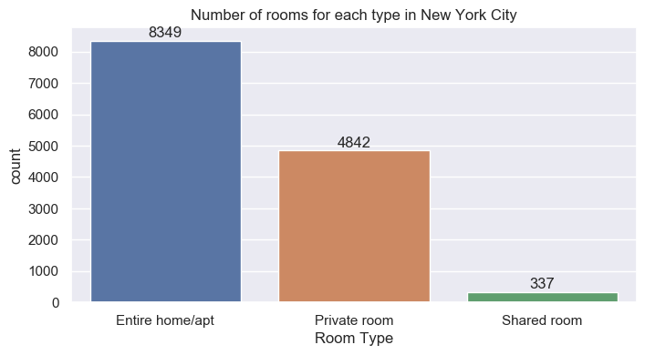

```python
plt.figure(figsize=(8,4), dpi=100)
room_counts = house_money['Room Type'].value_counts()
sb.countplot(x='Room Type',data=house_money)
plt.title("Number of rooms for each type in New York City")
for index,value in enumerate(room_counts.values):
    plt.annotate(value,(index,value+100),ha='center');
```

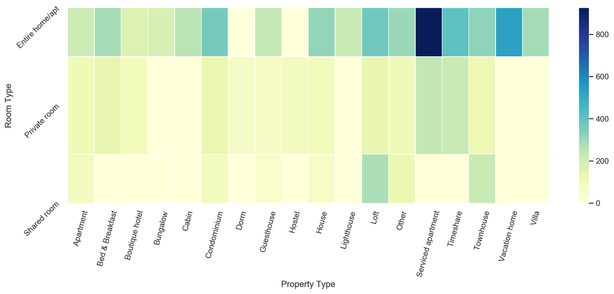

```python
# Number of property type in each location (bar-chart)
plt.figure(figsize=(15,5), dpi=200);
property_type, room_type, price = house_money['Property Type'], house_money['Room Type'], house_money['Price']
table = pd.pivot_table(house_money,columns='Property Type',index='Room Type',values='Price',aggfunc=np.mean).fillna(0)
sb.heatmap(table, linewidths=0.5, cmap='YlGnBu')
plt.xticks(rotation=75), plt.yticks(rotation=45);
```

#### Line Plot

In this plot, we will see how Airbnb becomes popular in NYC, which is one of primary purposes of this tutorial, based on number of listings and number of reviews over the months from 2009 to 2017.

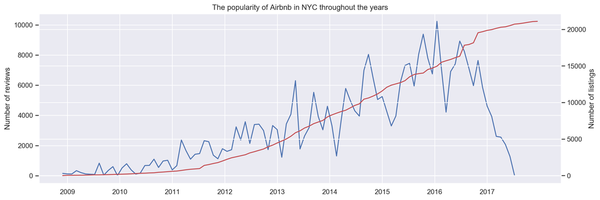

```python
# Number of reviews and number of host over each month (histogram)
review_months = pd.to_datetime(review_df['First Review'])
review_df['Month'],review_df['Year'] = review_months.apply(lambda x: x.month),review_months.apply(lambda x: x.year)
reviews = review_df.groupby(['Year','Month']).agg({"Number of Reviews":np.sum}).sort_index()

# Count the number of listings over the years to show the popularity of airbnb in nyc
# Because it mentions "since" -> cumulative
host_months = pd.to_datetime(host_df['Host Since'])
host_df['Month'],host_df['Year'] = host_months.apply(lambda x: x.month),host_months.apply(lambda x: x.year)
host_listings = host_df.groupby(['Year','Month']).agg({"Host Listings Count":np.sum}).astype(int)
time, listings = host_listings.index.values, [i[0] for i in host_listings.values]
listings = [np.sum(listings[:i+1]) for i in range(len(host_listings))]
host = pd.Series(listings, index=time)

fig, ax = plt.subplots(figsize=(15,5), dpi=200)
ax2 = ax.twinx()
plt.title("The popularity of Airbnb in NYC throughout the years")
plt.xlabel("Years"), ax2.set_ylabel('Number of listings'), ax.set_ylabel('Number of reviews')

ax2.plot(host.values, label='Number of listings',color='r')
ax.plot(reviews.values,label='Number of reviews',color='b')

plt.xticks(np.arange(1,100,11.5),['2009','2010','2011','2012','2013','2014','2015','2016','2017']);
```